# Application Activity 2

Hypothesis Testing and Confidence Intervals

Author

# Introduction

In this activity, you will execute statistical hypothesis tests and generate confidence intervals for each of the Big 5 personality traits using data collected from a random sample of Brother Cannon’s Math 221 students.

Begin by describing the population of this analysis. This will determine how broad our conclusions can be. Also include a table of the summary statistics and any visualizations that might tell a story about the data.  
**The population is brother Cannon’s math221 students.**

```r
# Load Libraries

library(tidyverse)
library(mosaic)
library(rio)


# Load Data
big5 <- import('https://raw.githubusercontent.com/byuistats/Math221D_Cannon/master/Data/All_class_combined_personality_data.csv')
```

**Agreeableness**

```r
fav <- favstats(big5$Agreeableness)
fav
```

```
 min Q1 median Q3 max     mean       sd   n missing
  21 67     75 81 100 73.43457 13.24909 405       0
```

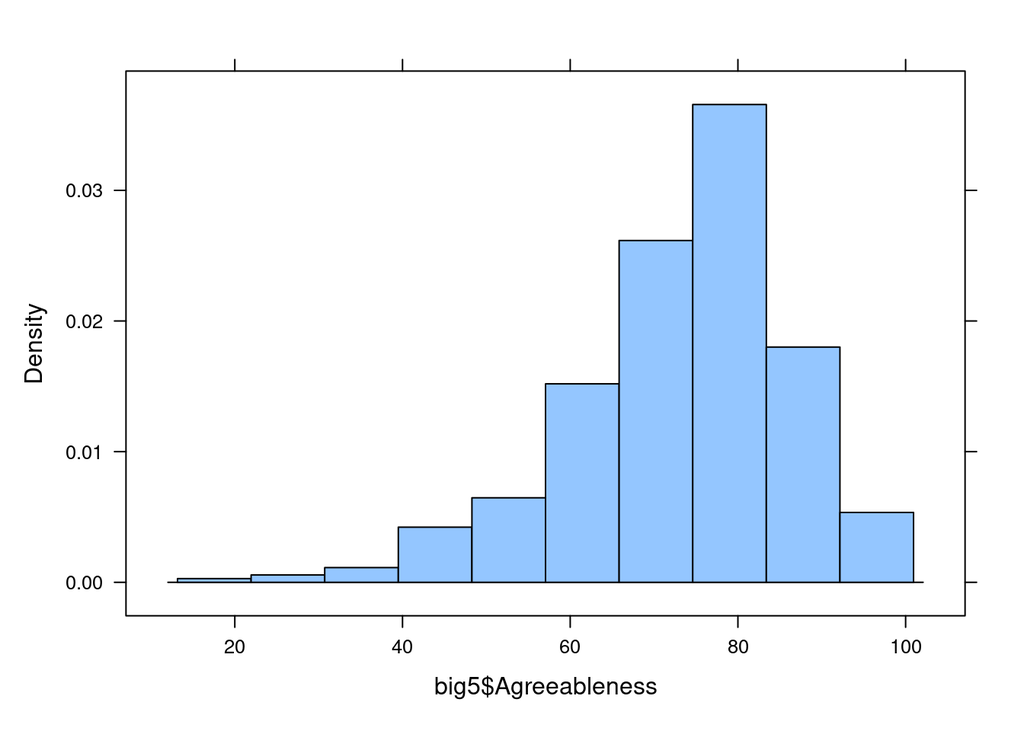

```r
histogram(big5$Agreeableness)
```

**Extroversion**

```r
fav <- favstats(big5$Extroversion)
fav
```

```
 min Q1 median Q3 max     mean       sd   n missing
   1 42     58 73 100 56.98267 21.09599 404       1
```

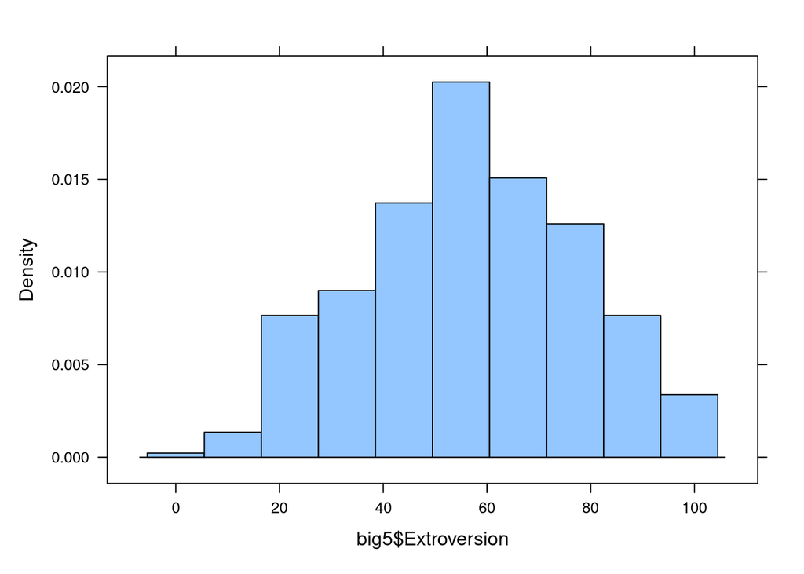

```r
histogram(big5$Extroversion)
```

**Openness**

```r
fav <- favstats(big5$Openness)
fav
```

```
 min Q1 median Q3 max     mean       sd   n missing
  10 60     73 83 100 71.81111 16.40637 405       0
```

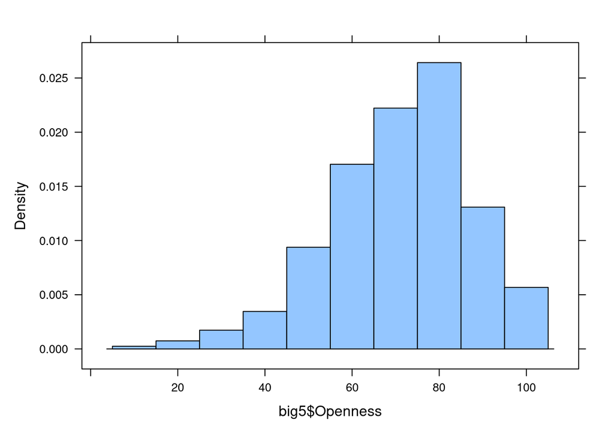

```r
histogram(big5$Openness)
```

**Neuroticism**

```r
fav <- favstats(big5$Neuroticism)
fav
```

```
 min Q1 median Q3 max     mean       sd   n missing
   0 35     48 60  92 47.39012 18.18166 405       0
```

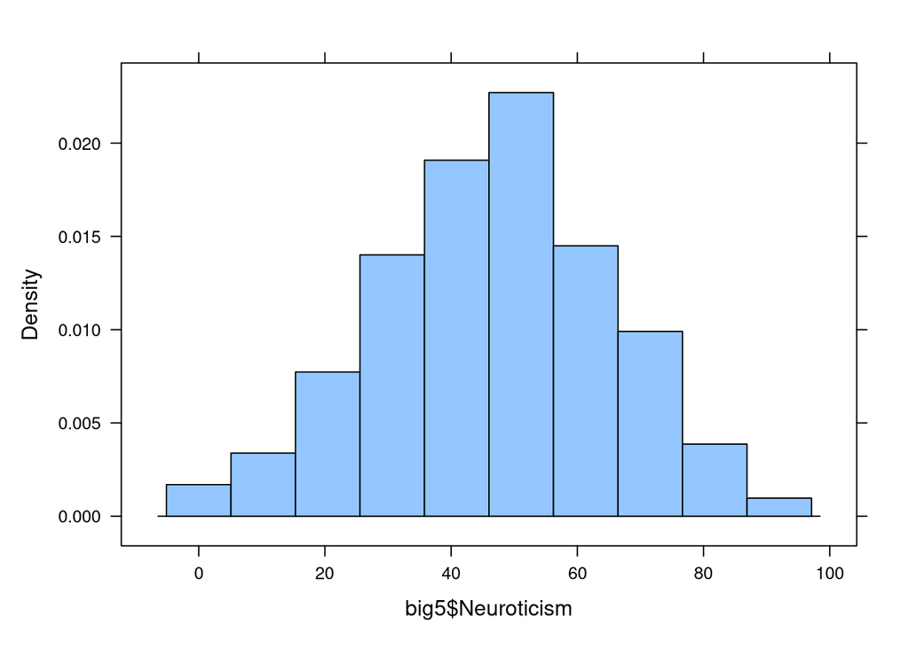

```r
histogram(big5$Neuroticism)
```

**Conscientiousness**

```r
fav <- favstats(big5$Conscientiousness)
fav
```

```
 min Q1 median Q3 max     mean       sd   n missing
   2 50     62 73  96 61.07901 16.55634 405       0
```

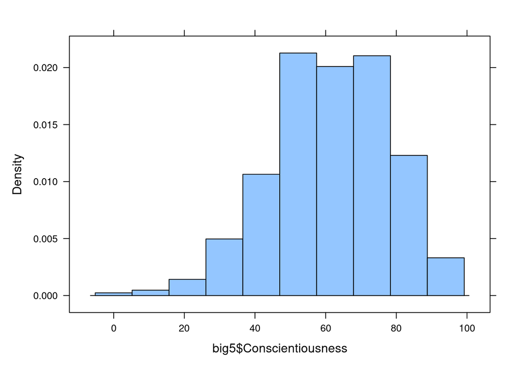

```r
histogram(big5$Conscientiousness)
```

Then, for each personality trait, include:

1. A statement of the null and alternative hypotheses and why you chose the alternative you did.
2. Choose alpha $= .5 $
3. Check that your test requirements are satisfied (`n > 30` or `qqPlot(respons_variable)`)
4. Run the one-sample t-test and state your conclusion
5. Calculate a $1-\alpha$ level confidence interval and describe in words what it means

Recall that we can use “favstats()” to get summary statistics, boxplot() and histogram() to get visualizations, and the t.test() function to get hypothesis tests and confidence intervals. **Be sure to label your plots’ axes and include a title.**

# Extroversion

H0: Mu = 50 Ha: Mu >50

alpha = .05

```r
# Extroversion

### I'm making a single variable called "extrov" that drops the missing values.  You can do the same thing with the other traits to make analysis a little easier
extrov <- na.omit(big5$Extroversion)

t.test(extrov, mu = 50, altenative= "greater")
```

```
    One Sample t-test

data:  extrov
t = 6.6529, df = 403, p-value = 9.394e-11
alternative hypothesis: true mean is not equal to 50
95 percent confidence interval:
 54.91937 59.04598
sample estimates:
mean of x
 56.98267
```

```r
t.test(extrov, mu = 50, altenative= "two.sided", conf.level = .95)
```

```
    One Sample t-test

data:  extrov
t = 6.6529, df = 403, p-value = 9.394e-11
alternative hypothesis: true mean is not equal to 50
95 percent confidence interval:
 54.91937 59.04598
sample estimates:
mean of x
 56.98267
```

## Conclusion

**The p-value is 9.394e-11 which is much lower than our alpha value so we reject the null hypothesis. We have sufficient evidence to suggest that brother Cannon’s students average extroverted scores are greater than 50. The confidence interval suggest that the true mean of the sample is between 54.91937 and 59.04598.**

# Agreeableness

H0: Mu = 50 Ha: Mu >50

alpha = .05

```r
# Agreeableness

agree <- na.omit(big5$Agreeableness)

t.test(agree, mu = 50, altenative= "greater")
```

```
    One Sample t-test

data:  agree
t = 35.596, df = 404, p-value < 2.2e-16
alternative hypothesis: true mean is not equal to 50
95 percent confidence interval:
 72.14034 74.72879
sample estimates:
mean of x
 73.43457
```

```r
t.test(agree, mu = 50, altenative= "two.sided", conf.level = .95)
```

```
    One Sample t-test

data:  agree
t = 35.596, df = 404, p-value < 2.2e-16
alternative hypothesis: true mean is not equal to 50
95 percent confidence interval:
 72.14034 74.72879
sample estimates:
mean of x
 73.43457
```

## Conclusion

**The p-value is < 2.2e-16 which is much lower than our alpha value so we reject the null hypothesis. We have sufficient evidence to suggest that brother Cannon’s students average agreeableness scores are greater than 50. The confidence interval suggest that the true mean of the sample is between 72.14034 and 74.72879.**

# Openness

H0: Mu = 50 Ha: Mu >50

alpha = .05

```r
# Openness

open <- na.omit(big5$Openness)

t.test(open, mu = 50, altenative= "greater")
```

```
    One Sample t-test

data:  open
t = 26.754, df = 404, p-value < 2.2e-16
alternative hypothesis: true mean is not equal to 50
95 percent confidence interval:
 70.20847 73.41375
sample estimates:
mean of x
 71.81111
```

```r
t.test(open, mu = 50, altenative= "two.sided", conf.level = .95)
```

```
    One Sample t-test

data:  open
t = 26.754, df = 404, p-value < 2.2e-16
alternative hypothesis: true mean is not equal to 50
95 percent confidence interval:
 70.20847 73.41375
sample estimates:
mean of x
 71.81111
```

## Conclusion

**The p-value is < 2.2e-16 which is much lower than our alpha value so we reject the null hypothesis. We have sufficient evidence to suggest that brother Cannon’s students average openness scores are greater than 50. The confidence interval suggest that the true mean of the sample is between 70.20847 and 73.41375.**

# Neuroticism

H0: Mu = 50 Ha: Mu >50

alpha = .05

```r
# Neuroticism

neuro <- na.omit(big5$Neuroticism)

t.test(neuro, mu = 50, altenative= "greater")
```

```
    One Sample t-test

data:  neuro
t = -2.8888, df = 404, p-value = 0.004076
alternative hypothesis: true mean is not equal to 50
95 percent confidence interval:
 45.61407 49.16618
sample estimates:
mean of x
 47.39012
```

```r
t.test(neuro, mu = 50, altenative= "two.sided", conf.level = .95)
```

```
    One Sample t-test

data:  neuro
t = -2.8888, df = 404, p-value = 0.004076
alternative hypothesis: true mean is not equal to 50
95 percent confidence interval:
 45.61407 49.16618
sample estimates:
mean of x
 47.39012
```

# Conscientiousness

H0: Mu = 50 Ha: Mu >50

alpha = .05

```r
# Conscientiousness
consc <- na.omit(big5$Conscientiousness)

t.test(consc, mu = 50, altenative= "greater")
```

```
    One Sample t-test

data:  consc
t = 13.467, df = 404, p-value < 2.2e-16
alternative hypothesis: true mean is not equal to 50
95 percent confidence interval:
 59.46172 62.69630
sample estimates:
mean of x
 61.07901
```

```r
t.test(consc, mu = 50, altenative= "two.sided", conf.level = .95)
```

```
    One Sample t-test

data:  consc
t = 13.467, df = 404, p-value < 2.2e-16
alternative hypothesis: true mean is not equal to 50
95 percent confidence interval:
 59.46172 62.69630
sample estimates:
mean of x
 61.07901
```

## Conclusion

**The p-value is < 2.2e-16 which is much lower than our alpha value so we reject the null hypothesis. We have sufficient evidence to suggest that brother Cannon’s students average conscientiousness scores are greater than 50. The confidence interval suggest that the true mean of the sample is between 59.46172 and 62.69630.**